# Part I - (Ford GoBike System Data Exploration)

## Introduction

This data contains information about individual rides made in a bike-sharing system covering the greater San Francisco Bay area.

## Preliminary Wrangling

```python
# import all packages and set plots to be embedded inline
import numpy as np
import pandas as pd
import matplotlib.pyplot as plt
import seaborn as sb

%matplotlib inline
```

```python
gobike = pd.read_csv('fordgobike.csv')
gobike
```

|  | duration_sec | start_time | end_time | start_station_id | start_station_name | start_station_latitude | start_station_longitude | end_station_id | end_station_name | end_station_latitude | end_station_longitude | bike_id | user_type | member_birth_year | member_gender | bike_share_for_all_trip |
| --- | --- | --- | --- | --- | --- | --- | --- | --- | --- | --- | --- | --- | --- | --- | --- | --- |
| 0 | 52185 | 2019-02-28 17:32:10.1450 | 2019-03-01 08:01:55.9750 | 21.0 | Montgomery St BART Station (Market St at 2nd St) | 37.789625 | -122.400811 | 13.0 | Commercial St at Montgomery St | 37.794231 | -122.402923 | 4902 | Customer | 1984.0 | Male | No |
| 1 | 42521 | 2019-02-28 18:53:21.7890 | 2019-03-01 06:42:03.0560 | 23.0 | The Embarcadero at Steuart St | 37.791464 | -122.391034 | 81.0 | Berry St at 4th St | 37.775880 | -122.393170 | 2535 | Customer | NaN | NaN | No |
| 2 | 61854 | 2019-02-28 12:13:13.2180 | 2019-03-01 05:24:08.1460 | 86.0 | Market St at Dolores St | 37.769305 | -122.426826 | 3.0 | Powell St BART Station (Market St at 4th St) | 37.786375 | -122.404904 | 5905 | Customer | 1972.0 | Male | No |
| 3 | 36490 | 2019-02-28 17:54:26.0100 | 2019-03-01 04:02:36.8420 | 375.0 | Grove St at Masonic Ave | 37.774836 | -122.446546 | 70.0 | Central Ave at Fell St | 37.773311 | -122.444293 | 6638 | Subscriber | 1989.0 | Other | No |
| 4 | 1585 | 2019-02-28 23:54:18.5490 | 2019-03-01 00:20:44.0740 | 7.0 | Frank H Ogawa Plaza | 37.804562 | -122.271738 | 222.0 | 10th Ave at E 15th St | 37.792714 | -122.248780 | 4898 | Subscriber | 1974.0 | Male | Yes |
| ... | ... | ... | ... | ... | ... | ... | ... | ... | ... | ... | ... | ... | ... | ... | ... | ... |
| 183407 | 480 | 2019-02-01 00:04:49.7240 | 2019-02-01 00:12:50.0340 | 27.0 | Beale St at Harrison St | 37.788059 | -122.391865 | 324.0 | Union Square (Powell St at Post St) | 37.788300 | -122.408531 | 4832 | Subscriber | 1996.0 | Male | No |
| 183408 | 313 | 2019-02-01 00:05:34.7440 | 2019-02-01 00:10:48.5020 | 21.0 | Montgomery St BART Station (Market St at 2nd St) | 37.789625 | -122.400811 | 66.0 | 3rd St at Townsend St | 37.778742 | -122.392741 | 4960 | Subscriber | 1984.0 | Male | No |
| 183409 | 141 | 2019-02-01 00:06:05.5490 | 2019-02-01 00:08:27.2200 | 278.0 | The Alameda at Bush St | 37.331932 | -121.904888 | 277.0 | Morrison Ave at Julian St | 37.333658 | -121.908586 | 3824 | Subscriber | 1990.0 | Male | Yes |
| 183410 | 139 | 2019-02-01 00:05:34.3600 | 2019-02-01 00:07:54.2870 | 220.0 | San Pablo Ave at MLK Jr Way | 37.811351 | -122.273422 | 216.0 | San Pablo Ave at 27th St | 37.817827 | -122.275698 | 5095 | Subscriber | 1988.0 | Male | No |
| 183411 | 271 | 2019-02-01 00:00:20.6360 | 2019-02-01 00:04:52.0580 | 24.0 | Spear St at Folsom St | 37.789677 | -122.390428 | 37.0 | 2nd St at Folsom St | 37.785000 | -122.395936 | 1057 | Subscriber | 1989.0 | Male | No |

183412 rows × 16 columns

```python
# high-level overview of data shape and composition
print(gobike.shape)
print(gobike.dtypes)
```

```
(183412, 16)
duration_sec                 int64
start_time                  object
end_time                    object
start_station_id           float64
start_station_name          object
start_station_latitude     float64
start_station_longitude    float64
end_station_id             float64
end_station_name            object
end_station_latitude       float64
end_station_longitude      float64
bike_id                      int64
user_type                   object
member_birth_year          float64
member_gender               object
bike_share_for_all_trip     object
dtype: object
```

```python
#convert the start_time and end_time columns to datetime datatype
gobike['start_time'] = pd.to_datetime(gobike['start_time'])
```

```python
gobike['end_time'] = pd.to_datetime(gobike['end_time'])
```

```python
#drop null values in start_station_id
gobike.dropna(subset=['start_station_id'], inplace=True)
```

```python
#convert start_station_id to int datatype
gobike['start_station_id'] = gobike['start_station_id'].astype(int)
```

```python
#convert end_station_id to int datatype
gobike['end_station_id'] = gobike['end_station_id'].astype(int)
```

```python
gobike.dtypes
```

```
duration_sec                        int64
start_time                 datetime64[ns]
end_time                   datetime64[ns]
start_station_id                    int32
start_station_name                 object
start_station_latitude            float64
start_station_longitude           float64
end_station_id                      int32
end_station_name                   object
end_station_latitude              float64
end_station_longitude             float64
bike_id                             int64
user_type                          object
member_birth_year                 float64
member_gender                      object
bike_share_for_all_trip            object
dtype: object
```

```python
print(gobike.shape)
```

```
(183215, 16)
```

### What is the structure of your dataset?

This dataset originally contains information about 183,412 gobike rides in the San Francisco Bay area with 16 attributes, detailing the times of rental and return, names of rental station and return, and information about the people borrowing the bikes.

### What is/are the main feature(s) of interest in your dataset?

I am interested in how the customer and subscriber user-types differ from one another.

### What features in the dataset do you think will help support your investigation into your feature(s) of interest?

I expect that the distance covered, the time of the day, age and gender attributes are important features to help understand the differences and patterns between the two user groups.

## Univariate Exploration

In this section, I'd be looking to investigate the distribution of individual variables and to achieve this I'd be answering the following questions:

- What is the distribution of the different users?
- What is the gender distribution of riders?
- What is the age distribution of riders?
- What time of the day are most rides taken?
- What day of the week are most rides taken?
- What is the distribution of ride duration?
- What is the distribution of distance covered?

### Question

What is the distribution of the different users?

### Visualization

```python
#funtion to label x and y axis and plot titles
def label(x, y, title):
    """
    x(str): x-axis title
    y(str): y-axis title
    title: Plot main title

    Returns: None
    """
    plt.xlabel(x)
    plt.ylabel(y)
    plt.title(title, pad=20);
```

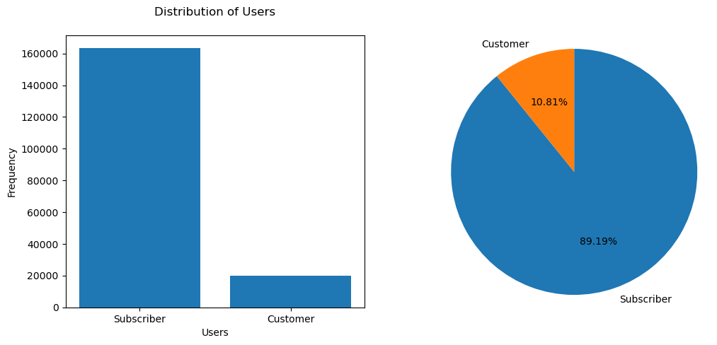

```python
user = gobike['user_type'].value_counts()

plt.figure(figsize=[12,5])

plt.subplot(1,2,1)
plt.bar(user.index, user.values)
label('Users', 'Frequency', 'Distribution of Users');

plt.subplot(1,2,2)
plt.pie(user, labels = user.index, startangle = 90,
        counterclock = False, autopct='%1.2f%%');
plt.axis('square');
```

### Observation

It can be seen that there are more Subcribers than the Customers with the Subscribers having over 160 thousand rides to Customers of about 20 thousand rides.

### Question

What is the gender distribution of riders?

### Visualization

```python
#Creating a copy of the data for gender analysis
gender = gobike.copy()
```

```python
gender.dropna(subset='member_gender', inplace=True)
```

```python
g= gender.member_gender.value_counts()
```

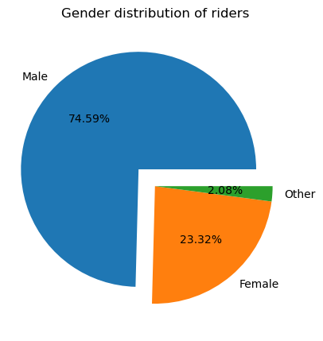

```python
y = np.array(g.values)
plt.pie(y, labels = g.index, explode=[0.2, 0, 0], autopct='%1.2f%%')
plt.title('Gender distribution of riders', pad=20);
```

### Observation

The gender distribution shows that there are three categories of genders, the Male, Female and Other gender.

### Question

What is the age distribution of riders?

### Visualization

```python
gobike.dropna(subset='member_birth_year', inplace=True)
```

```python
gobike['member_birth_year'] = gobike['member_birth_year'].astype(int)
```

```python
for i in gobike['member_birth_year']:
    gobike['member_age'] = 2019 - gobike['member_birth_year']
```

```python
gobike.head()
```

|  | duration_sec | start_time | end_time | start_station_id | start_station_name | start_station_latitude | start_station_longitude | end_station_id | end_station_name | end_station_latitude | end_station_longitude | bike_id | user_type | member_birth_year | member_gender | bike_share_for_all_trip | member_age |
| --- | --- | --- | --- | --- | --- | --- | --- | --- | --- | --- | --- | --- | --- | --- | --- | --- | --- |
| 0 | 52185 | 2019-02-28 17:32:10.145 | 2019-03-01 08:01:55.975 | 21 | Montgomery St BART Station (Market St at 2nd St) | 37.789625 | -122.400811 | 13 | Commercial St at Montgomery St | 37.794231 | -122.402923 | 4902 | Customer | 1984 | Male | No | 35 |
| 2 | 61854 | 2019-02-28 12:13:13.218 | 2019-03-01 05:24:08.146 | 86 | Market St at Dolores St | 37.769305 | -122.426826 | 3 | Powell St BART Station (Market St at 4th St) | 37.786375 | -122.404904 | 5905 | Customer | 1972 | Male | No | 47 |
| 3 | 36490 | 2019-02-28 17:54:26.010 | 2019-03-01 04:02:36.842 | 375 | Grove St at Masonic Ave | 37.774836 | -122.446546 | 70 | Central Ave at Fell St | 37.773311 | -122.444293 | 6638 | Subscriber | 1989 | Other | No | 30 |
| 4 | 1585 | 2019-02-28 23:54:18.549 | 2019-03-01 00:20:44.074 | 7 | Frank H Ogawa Plaza | 37.804562 | -122.271738 | 222 | 10th Ave at E 15th St | 37.792714 | -122.248780 | 4898 | Subscriber | 1974 | Male | Yes | 45 |
| 5 | 1793 | 2019-02-28 23:49:58.632 | 2019-03-01 00:19:51.760 | 93 | 4th St at Mission Bay Blvd S | 37.770407 | -122.391198 | 323 | Broadway at Kearny | 37.798014 | -122.405950 | 5200 | Subscriber | 1959 | Male | No | 60 |

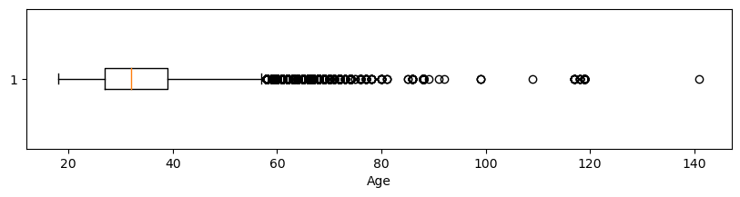

```python
plt.figure(figsize=[10,2])
plt.boxplot(gobike['member_age'], vert=False)
plt.xlabel('Age');
```

```python
#dropping riders with age over 95
gobike = gobike.query('member_age <95')
```

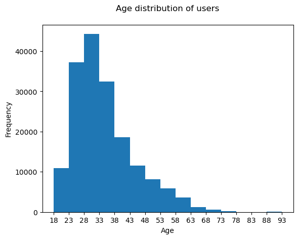

```python
binsize=5
bins= np.arange(gobike.member_age.min(), gobike.member_age.max()+binsize, binsize)

plt.hist(data=gobike, x= 'member_age', bins = bins)
plt.xticks(bins)
label('Age', 'Frequency', 'Age distribution of users');
```

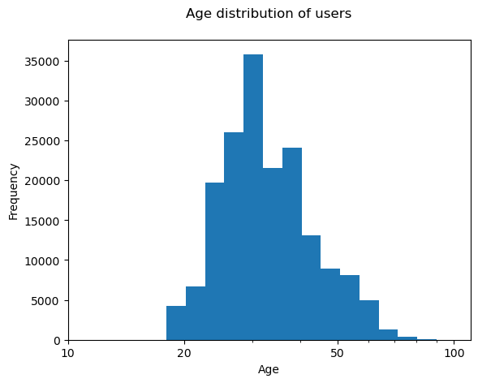

```python
## there's a long tail in the distribution, so let's put it on a log scale instead
log_binsize = 0.05
bins= 10 ** np.arange(np.log10(gobike.member_age.min()), np.log10(gobike.member_age.max())+log_binsize, log_binsize)

plt.hist(data=gobike, x= 'member_age', bins = bins)
plt.xscale('log')
label('Age', 'Frequency', 'Age distribution of users')
plt.xticks([10, 20, 50, 100], [10, 20, 50, 100]);
```

### Observation

It can be observed that the distribution is skewed to the right and most riders are between the ages 23 - 38. Also, there are many outliers and for the cause of this project, it has been assumed that ages 95 and above aren't riders and are excluded from the data.

### Question

What time of the day are most rides taken?

```python
#extracting hours from the start time column
hour = gobike['start_time'].dt.hour
```

```python
#creating the time of day attribute from the start time column using pd.cut
gobike.loc[:, 'time_of_day'] = pd.cut(x=hour, bins=[0, 4, 8, 12, 16, 20, 24], labels=['Late Night', 'Early Morning',
                                                                              'Morning', 'Afternoon', 'Evening', 'Night'],
                              right=False)
```

```python
#converting the datatype of time_of_day into an ordered category
tod = ['Late Night', 'Early Morning', 'Morning', 'Afternoon', 'Evening', 'Night']
classes = pd.api.types.CategoricalDtype(ordered=True, categories=tod)
gobike['time_of_day'] = gobike['time_of_day'].astype(classes)
```

```python
gobike['time_of_day'].value_counts()
```

```
Evening          59886
Morning          50842
Afternoon        32628
Night            14974
Early Morning    14610
Late Night        1937
Name: time_of_day, dtype: int64
```

### Visualization

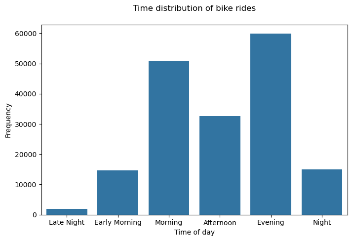

```python
base_color = sb.color_palette()[0]
plt.figure(figsize=[8,5])
sb.countplot(data=gobike, x='time_of_day', color=base_color)
label('Time of day', 'Frequency', 'Time distribution of bike rides');
```

### Observation

It can be seen that the most rides are taken in the Evening (hours 16:00 to 20:00) then followed by Morning (hours 8:00 to 12:00). The least rides are taken at Late nights (0:00 - 4:00).

### Question

What day of the week are most rides taken?

### Visualization

```python
#extracting day of week from start time column
gobike.loc[:,'day_of_week'] = gobike['start_time'].dt.day_name()
```

```python
#converting the datatype of day_of_week into an ordered category
dow = ['Monday', 'Tuesday', 'Wednesday', 'Thursday', 'Friday', 'Saturday', 'Sunday']
classes = pd.api.types.CategoricalDtype(ordered=True, categories=dow)
gobike['day_of_week'] = gobike['day_of_week'].astype(classes)
```

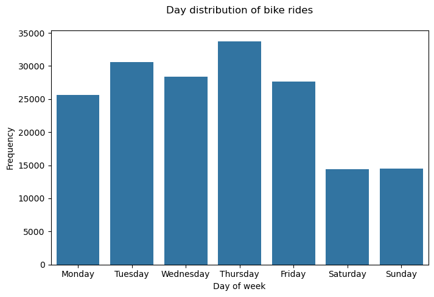

```python
base_color = sb.color_palette()[0]
plt.figure(figsize=[8,5])
sb.countplot(data=gobike, x='day_of_week', color=base_color)
label('Day of week', 'Frequency', 'Day distribution of bike rides');
```

### Question

What is the distribution of ride duration?

### Visualization

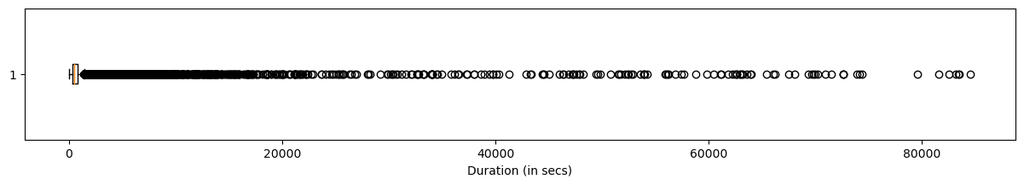

```python
plt.figure(figsize=[15,2])
plt.boxplot(gobike['duration_sec'], vert=False)
plt.xlabel('Duration (in secs)');
```

```python
gobike.query('duration_sec > 1400')
```

|  | duration_sec | start_time | end_time | start_station_id | start_station_name | start_station_latitude | start_station_longitude | end_station_id | end_station_name | end_station_latitude | end_station_longitude | bike_id | user_type | member_birth_year | member_gender | bike_share_for_all_trip | member_age | time_of_day | day_of_week |
| --- | --- | --- | --- | --- | --- | --- | --- | --- | --- | --- | --- | --- | --- | --- | --- | --- | --- | --- | --- |
| 0 | 52185 | 2019-02-28 17:32:10.145 | 2019-03-01 08:01:55.975 | 21 | Montgomery St BART Station (Market St at 2nd St) | 37.789625 | -122.400811 | 13 | Commercial St at Montgomery St | 37.794231 | -122.402923 | 4902 | Customer | 1984 | Male | No | 35 | Evening | Thursday |
| 2 | 61854 | 2019-02-28 12:13:13.218 | 2019-03-01 05:24:08.146 | 86 | Market St at Dolores St | 37.769305 | -122.426826 | 3 | Powell St BART Station (Market St at 4th St) | 37.786375 | -122.404904 | 5905 | Customer | 1972 | Male | No | 47 | Afternoon | Thursday |
| 3 | 36490 | 2019-02-28 17:54:26.010 | 2019-03-01 04:02:36.842 | 375 | Grove St at Masonic Ave | 37.774836 | -122.446546 | 70 | Central Ave at Fell St | 37.773311 | -122.444293 | 6638 | Subscriber | 1989 | Other | No | 30 | Evening | Thursday |
| 4 | 1585 | 2019-02-28 23:54:18.549 | 2019-03-01 00:20:44.074 | 7 | Frank H Ogawa Plaza | 37.804562 | -122.271738 | 222 | 10th Ave at E 15th St | 37.792714 | -122.248780 | 4898 | Subscriber | 1974 | Male | Yes | 45 | Night | Thursday |
| 5 | 1793 | 2019-02-28 23:49:58.632 | 2019-03-01 00:19:51.760 | 93 | 4th St at Mission Bay Blvd S | 37.770407 | -122.391198 | 323 | Broadway at Kearny | 37.798014 | -122.405950 | 5200 | Subscriber | 1959 | Male | No | 60 | Night | Thursday |
| ... | ... | ... | ... | ... | ... | ... | ... | ... | ... | ... | ... | ... | ... | ... | ... | ... | ... | ... | ... |
| 183165 | 2870 | 2019-02-01 06:07:09.568 | 2019-02-01 06:54:59.714 | 304 | Jackson St at 5th St | 37.348759 | -121.894798 | 292 | Empire St at 1st St | 37.344882 | -121.896965 | 3916 | Subscriber | 1957 | Male | Yes | 62 | Early Morning | Friday |
| 183317 | 1476 | 2019-02-01 02:45:04.744 | 2019-02-01 03:09:41.184 | 345 | Hubbell St at 16th St | 37.766483 | -122.398279 | 345 | Hubbell St at 16th St | 37.766483 | -122.398279 | 5224 | Subscriber | 1967 | Male | No | 52 | Late Night | Friday |
| 183326 | 5713 | 2019-02-01 01:02:55.168 | 2019-02-01 02:38:09.002 | 31 | Raymond Kimbell Playground | 37.783813 | -122.434559 | 31 | Raymond Kimbell Playground | 37.783813 | -122.434559 | 5366 | Subscriber | 1972 | Male | No | 47 | Late Night | Friday |
| 183328 | 2822 | 2019-02-01 01:49:07.256 | 2019-02-01 02:36:10.183 | 152 | 47th St at San Pablo Ave | 37.835632 | -122.281051 | 211 | Broadway at 40th St | 37.827757 | -122.256716 | 4476 | Subscriber | 1989 | Male | No | 30 | Late Night | Friday |
| 183372 | 1409 | 2019-02-01 00:47:33.358 | 2019-02-01 01:11:02.443 | 230 | 14th St at Mandela Pkwy | 37.810743 | -122.291415 | 150 | Adeline St at 40th St | 37.831277 | -122.278267 | 3615 | Subscriber | 1989 | Male | No | 30 | Late Night | Friday |

10853 rows × 19 columns

```python
gobike = gobike.query('duration_sec < 1400')
```

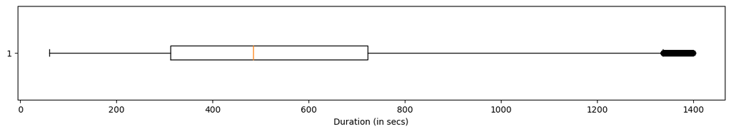

```python
plt.figure(figsize=[15,2])
plt.boxplot(gobike['duration_sec'], vert=False)
plt.xlabel('Duration (in secs)');
```

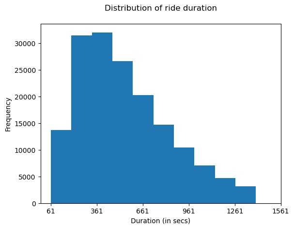

```python
binsize=300
bins= np.arange(gobike.duration_sec.min(), gobike.duration_sec.max()+binsize, binsize)

plt.hist(data=gobike, x= 'duration_sec', bins = 10)
plt.xticks(bins)
label('Duration (in secs)', 'Frequency', 'Distribution of ride duration');
```

### Observation

It can be seen that most rides taken last about 300 secs (5 minutes) to 700 secs (11+ minutes). Few rides last for over 1000 secs (16+ mins).

### Question

What is the distribution of distance covered?

### Visualization

```python
#Defining a function to convert latitude & longitude coords to kms using geopy library so .apply method can be used on all rows.
import geopy.distance
def distance(coords1, coords2):
    return round(geopy.distance.geodesic(coords1, coords2).km, 2)

gobike['distance'] = gobike.apply(lambda x: distance((x['start_station_latitude'], x['start_station_longitude']),
                                                       (x['end_station_latitude'], x['end_station_longitude'])), axis=1)
```

```python
gobike.head()
```

|  | duration_sec | start_time | end_time | start_station_id | start_station_name | start_station_latitude | start_station_longitude | end_station_id | end_station_name | end_station_latitude | end_station_longitude | bike_id | user_type | member_birth_year | member_gender | bike_share_for_all_trip | member_age | time_of_day | day_of_week | distance |
| --- | --- | --- | --- | --- | --- | --- | --- | --- | --- | --- | --- | --- | --- | --- | --- | --- | --- | --- | --- | --- |
| 6 | 1147 | 2019-02-28 23:55:35.104 | 2019-03-01 00:14:42.588 | 300 | Palm St at Willow St | 37.317298 | -121.884995 | 312 | San Jose Diridon Station | 37.329732 | -121.901782 | 3803 | Subscriber | 1983 | Female | No | 36 | Night | Thursday | 2.03 |
| 9 | 1049 | 2019-02-28 23:49:47.699 | 2019-03-01 00:07:17.025 | 19 | Post St at Kearny St | 37.788975 | -122.403452 | 121 | Mission Playground | 37.759210 | -122.421339 | 6488 | Subscriber | 1992 | Male | No | 27 | Night | Thursday | 3.66 |
| 10 | 458 | 2019-02-28 23:57:57.211 | 2019-03-01 00:05:35.435 | 370 | Jones St at Post St | 37.787327 | -122.413278 | 43 | San Francisco Public Library (Grove St at Hyde... | 37.778768 | -122.415929 | 5318 | Subscriber | 1996 | Female | Yes | 23 | Night | Thursday | 0.98 |
| 11 | 506 | 2019-02-28 23:56:55.540 | 2019-03-01 00:05:21.733 | 44 | Civic Center/UN Plaza BART Station (Market St ... | 37.781074 | -122.411738 | 343 | Bryant St at 2nd St | 37.783172 | -122.393572 | 5848 | Subscriber | 1993 | Male | No | 26 | Night | Thursday | 1.62 |
| 12 | 1176 | 2019-02-28 23:45:12.651 | 2019-03-01 00:04:49.184 | 127 | Valencia St at 21st St | 37.756708 | -122.421025 | 323 | Broadway at Kearny | 37.798014 | -122.405950 | 5328 | Customer | 1990 | Male | No | 29 | Night | Thursday | 4.77 |

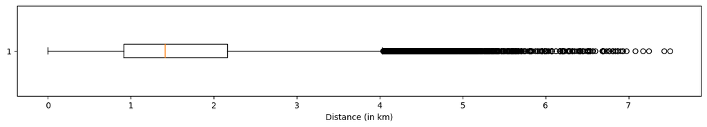

```python
plt.figure(figsize=[15,2])
plt.boxplot(gobike['distance'], vert=False)
plt.xlabel('Distance (in km)');
```

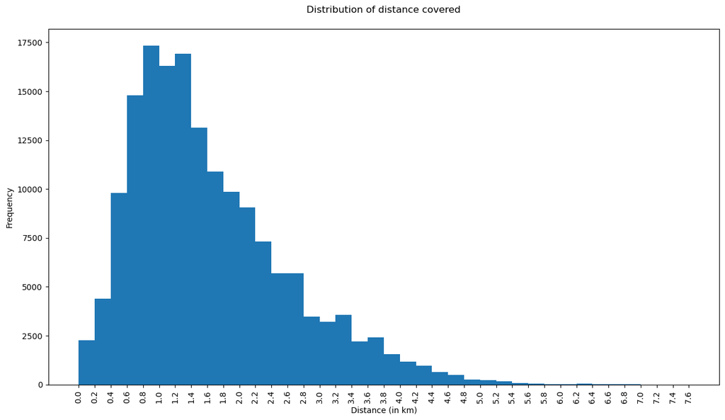

```python
binsize=0.2
bins= np.arange(gobike.distance.min(), gobike.distance.max()+binsize, binsize)

plt.figure(figsize=[15,8])
plt.hist(data=gobike, x= 'distance', bins = bins)
plt.xticks(bins, rotation = 90)
label('Distance (in km)','Frequency','Distribution of distance covered');
```

```python
gobike.distance.describe()
```

```
count    164004.000000
mean          1.633628
std           0.975950
min           0.000000
25%           0.910000
50%           1.410000
75%           2.160000
max           7.500000
Name: distance, dtype: float64
```

### Observation

It can be seen that most rides are between 0.5km and 2.2km with many outliers from 4.2km and above.

## Bivariate Exploration

- What is the gender distribution across the different users
- What is the age distribution across the different users
- Does the time of day of most rides taken differ amongst the users
- Do users differ by rides taken at different days of the week
- Do users differ by the time duration of completed trips
- What is the distribution of distance covered for different users
- Is there a correlation between age and distance covered?
- Is there a correlation between distance covered and duration of trip

### Question

What is the distribution of users against the gender category

### Visualization

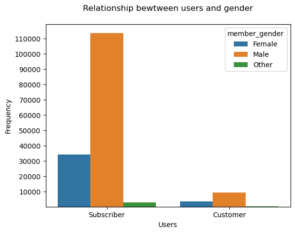

```python
sb.countplot(data = gobike, x = 'user_type', hue = 'member_gender')

binsize=10000
bins = np.arange(10000, 120000, binsize)
plt.yticks(bins)
label('Users', 'Frequency', 'Relationship bewtween users and gender');
```

```python
#Visualising using heat map - preparing the data by creating a new dataframe
users = gobike.groupby(['user_type', 'member_gender']).size()
users
```

```
user_type   member_gender
Customer    Female             3536
            Male               9406
            Other               377
Subscriber  Female            34175
            Male             113613
            Other              2897
dtype: int64
```

```python
users = users.reset_index(name='count')
users
```

|  | user_type | member_gender | count |
| --- | --- | --- | --- |
| 0 | Customer | Female | 3536 |
| 1 | Customer | Male | 9406 |
| 2 | Customer | Other | 377 |
| 3 | Subscriber | Female | 34175 |
| 4 | Subscriber | Male | 113613 |
| 5 | Subscriber | Other | 2897 |

```python
#arranging the data using df.pivot
users = users.pivot(index = 'user_type', columns = 'member_gender', values='count')
users
```

| member_gender user_type | Female | Male | Other |
| --- | --- | --- | --- |
| Customer | 3536 | 9406 | 377 |
| Subscriber | 34175 | 113613 | 2897 |

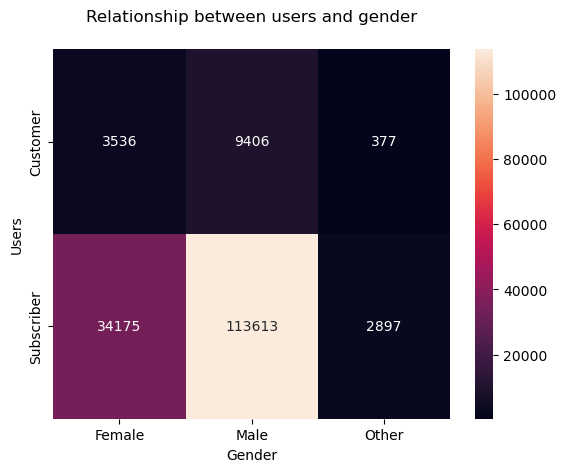

```python
sb.heatmap(users, annot=True, fmt='d')
label('Gender', 'Users', 'Relationship between users and gender');
```

### Observation

For the Subscriber category of users, the most by a large number is the Male gender followed by the Female and the Other gender. It follows the same pattern for the Customer category.

### Question

What is the age distribution across the different users

### Visualization

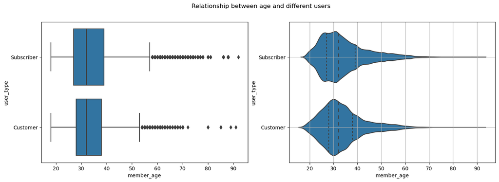

```python
base_color = sb.color_palette()[0]
plt.figure(figsize = [16, 5])

plt.subplot(1, 2, 1)
sb.boxplot(data=gobike, y='user_type', x='member_age', color=base_color);

plt.subplot(1, 2, 2)
sb.violinplot(data=gobike, y='user_type', x='member_age', color=base_color, inner='quartile')
plt.suptitle('Relationship between age and different users')
plt.grid();
```

### Observation

From the violin plot, the Subscriber category seems to be slightly bimodal and the Customer category is unimodal. The median age of both category of users are about the same at about 32.

### Question

Does the time of day of most rides taken differ amongst the users

### Visualization

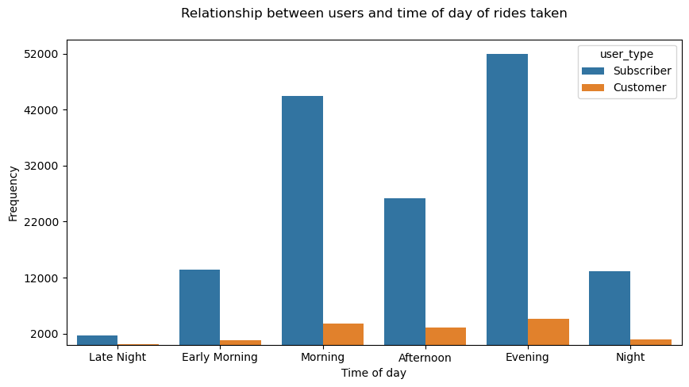

```python
plt.figure(figsize= [10, 5])
sb.countplot(data = gobike, hue = 'user_type', x = 'time_of_day')

bins = np.arange(2000,55000,10000)
plt.yticks(bins)
label('Time of day', 'Frequency', 'Relationship between users and time of day of rides taken');
```

```python
#rearranging the data to plot a heatmap
h= gobike.groupby(['user_type', 'time_of_day']).size().reset_index(name='count').pivot(index='user_type', columns='time_of_day',
                                                                                   values='count')
h
```

| time_of_day user_type | Late Night | Early Morning | Morning | Afternoon | Evening | Night |
| --- | --- | --- | --- | --- | --- | --- |
| Customer | 143 | 828 | 3759 | 3039 | 4594 | 956 |
| Subscriber | 1619 | 13360 | 44512 | 26114 | 51950 | 13130 |

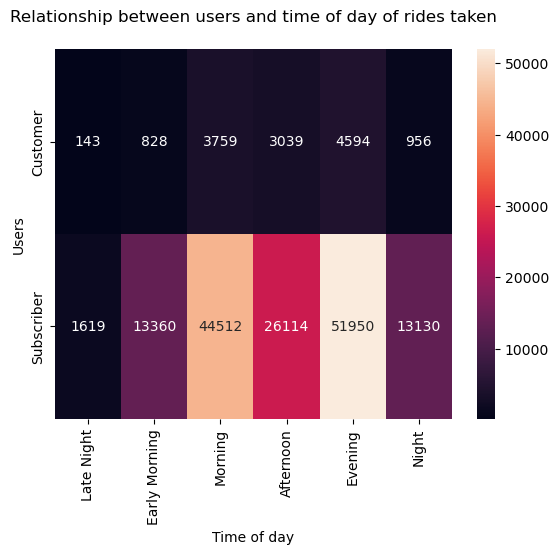

```python
sb.heatmap(h, annot=True, fmt='d')
plt.title('Relationship between users and time of day of rides taken')
label('Time of day', 'Users', 'Relationship between users and time of day of rides taken');
```

### Observation

It can be seen that the rides taken at different times of the day follows the same pattern for both Subscriber and Customer with Evenings and Mornings still being the most times rides are taken.

### Question

Do users differ by rides taken at different days of the week

### Visualization

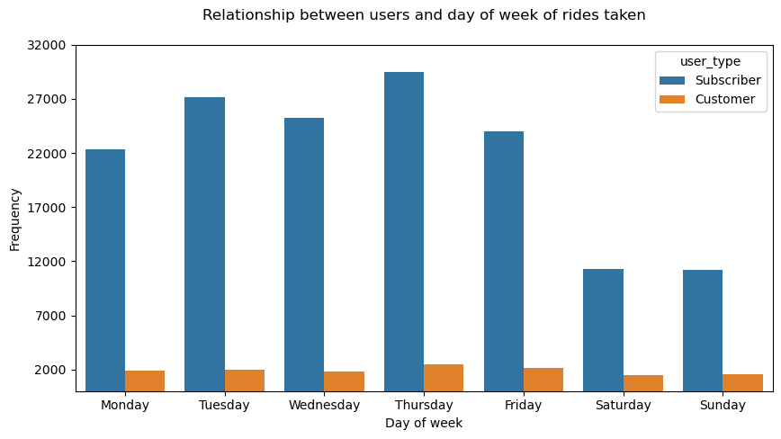

```python
plt.figure(figsize= [10, 5])
sb.countplot(data = gobike, hue = 'user_type', x = 'day_of_week')

bins = np.arange(2000,35000,5000)
plt.yticks(bins)
label('Day of week', 'Frequency', 'Relationship between users and day of week of rides taken');
```

```python
#rearranging the data to plot a heatmap
i= gobike.groupby(['user_type', 'day_of_week']).size().reset_index(name='count').pivot(index='user_type', columns='day_of_week',
                                                                                   values='count')
i
```

| day_of_week user_type | Monday | Tuesday | Wednesday | Thursday | Friday | Saturday | Sunday |
| --- | --- | --- | --- | --- | --- | --- | --- |
| Customer | 1865 | 1980 | 1830 | 2466 | 2114 | 1509 | 1555 |
| Subscriber | 22324 | 27159 | 25273 | 29484 | 24009 | 11246 | 11190 |

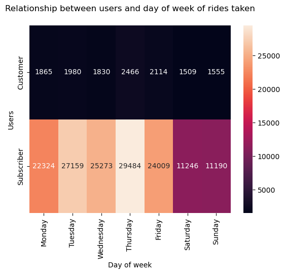

```python
sb.heatmap(i, annot=True, fmt='d')
label('Day of week', 'Users', 'Relationship between users and day of week of rides taken');
```

### Observation

Here, the most rides taken at different days of the week differ by the users. For the Subcribers, the most rides are taken on Thursday, followed by Tuesday and Wednesday. For Customers, although the most rides are taken on Thursday like the Subcriber class, it is followed by Friday and Tuesday. The least day for rides taken for Subscribers is Sunday while that of the Customers is Saturday.

### Question

Do users differ by the time duration of completed trips

### Visualization

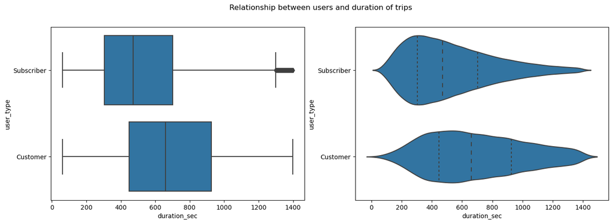

```python
base_color = sb.color_palette()[0]
plt.figure(figsize = [16, 5])
plt.suptitle('Relationship between users and duration of trips')

plt.subplot(1, 2, 1)
sb.boxplot(data=gobike, y='user_type', x='duration_sec', color=base_color);

plt.subplot(1, 2, 2)
sb.violinplot(data=gobike, y='user_type', x='duration_sec', color=base_color, inner='quartile');
```

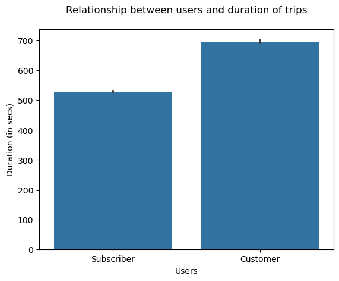

```python
sb.barplot(data=gobike, x='user_type', y='duration_sec', color=base_color)
label('Users', 'Duration (in secs)', 'Relationship between users and duration of trips');
```

### Observation

The average duration of trips taken by the Customers is more than the Subscribers. This implies that Customers spend more time on their trips on the average.

### Question

What is the distribution of distance covered for different users

### Visualization

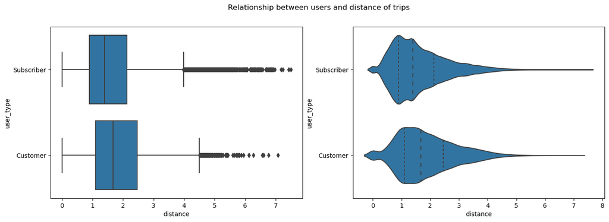

```python
base_color = sb.color_palette()[0]
plt.figure(figsize = [16, 5])
plt.suptitle('Relationship between users and distance of trips')

plt.subplot(1, 2, 1)
sb.boxplot(data=gobike, y='user_type', x='distance', color=base_color);

plt.subplot(1, 2, 2)
sb.violinplot(data=gobike, y='user_type', x='distance', color=base_color, inner='quartile');
```

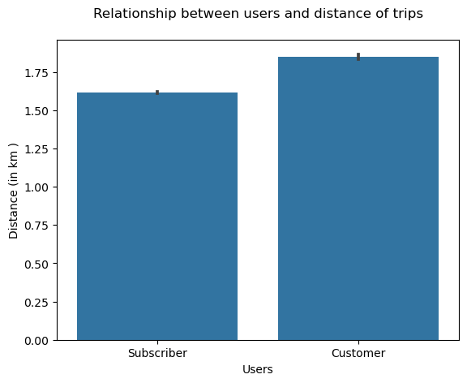

```python
sb.barplot(data=gobike, x='user_type', y='distance', color=base_color)
label('Users', 'Distance (in km )', 'Relationship between users and distance of trips');
```

### Observation

The observation is similar to the relationship between the users and the duration spent on trips as Customers spend more time on trips than Subscribers on the average.

### Question

Is there a correlation between distance covered and duration of trip

### Visualization

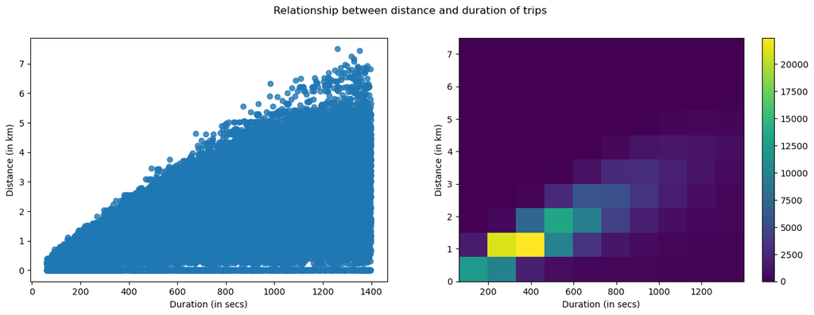

```python
plt.figure(figsize = [16, 5])
plt.suptitle('Relationship between distance and duration of trips')

#figure1
plt.subplot(1,2,1)
sb.regplot(data = gobike, x = 'duration_sec', y = 'distance')
label('Duration (in secs)', 'Distance (in km)', '');

#figure2
plt.subplot(1,2,2)
plt.hist2d(data = gobike, x = 'duration_sec', y = 'distance')
plt.colorbar()
label('Duration (in secs)', 'Distance (in km)', '');
```

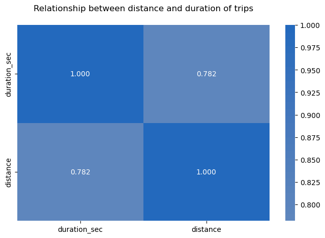

```python
# correlation plot between distance and duration of trip

numeric_vars = ['duration_sec', 'distance']
plt.figure(figsize = [8, 5])
sb.heatmap(gobike[numeric_vars].corr(), annot = True, fmt = '.3f',
           cmap = 'vlag_r', center = 0)
plt.title('Relationship between distance and duration of trips', pad=20)
plt.show();
```

### Observation

As expected there is a strong positive correlation between distance of trips and the duration of the trips. Longer trips take more time to finish.

### Question

Is there a correlation between age and distance covered?

### Visualization

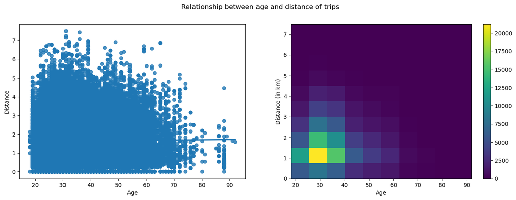

```python
plt.figure(figsize = [16, 5])
plt.suptitle('Relationship between age and distance of trips')

#figure1
plt.subplot(1,2,1)
sb.regplot(data = gobike, x = 'member_age', y = 'distance')
label('Age', 'Distance (in km)', '');

#figure2
plt.subplot(1,2,2)
plt.hist2d(data = gobike, x = 'member_age', y = 'distance')
plt.colorbar()
label('Age', 'Distance (in km)', '');
```

### Observation

From the scatter plot it can be seen that there's no correlation between both variables as user's ages have no influence on the distance of the trips. Since there is a positive correlation between distance and duration of trips, it can be implied that there would be no correlation between ages and duration of trips.

### Talk about some of the relationships you observed in this part of the investigation. How did the feature(s) of interest vary with other features in the dataset?

It was observed that Customers spend more time and go longer distances on their rides than an average Subscriber would. Also, the most trips are taken on Thursdays, more than any other day. The least trips are taken on weekends.

### Did you observe any interesting relationships between the other features (not the main feature(s) of interest)?

As expected, there is a positive correlation between distance of trips and their duration but the age of users have no influence on the distance and duration.

## Multivariate Exploration

- How does the distance covered vary across different users and their gender
- How does the distance covered vary across different times of day for the users
- How does the distance covered vary across different days of the week for the users
- How do the different users vary by distance and duration of trips

### Question

How does the distance covered vary across different users and their gender

### Visualization

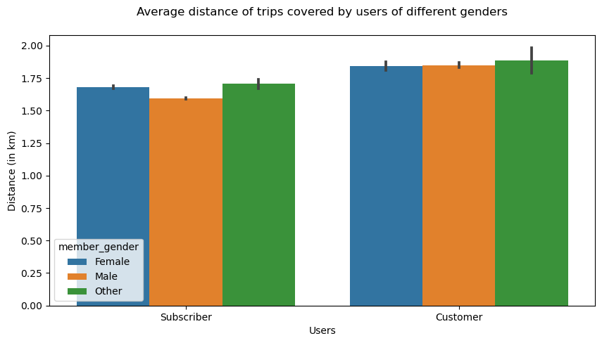

```python
plt.figure(figsize= [10, 5])
sb.barplot(data = gobike, x = 'user_type', hue = 'member_gender', y='distance')
label('Users', 'Distance (in km)', 'Average distance of trips covered by users of different genders');
```

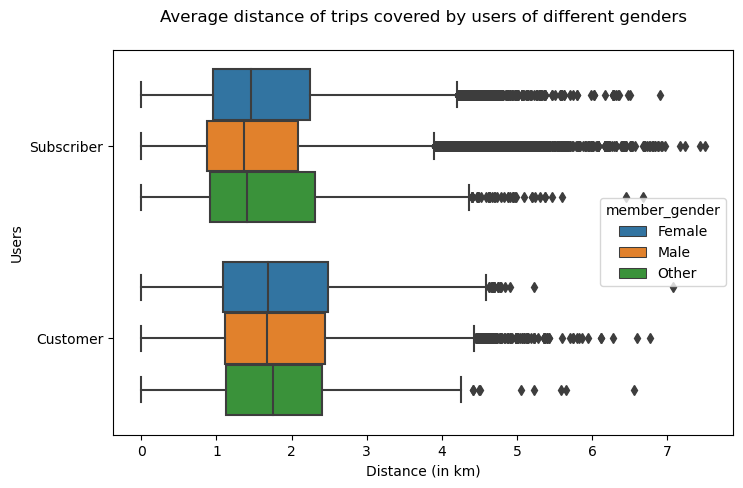

```python
plt.figure(figsize=[8,5])
sb.boxplot(data = gobike, y = 'user_type', hue = 'member_gender', x='distance')
label('Distance (in km)', 'Users', 'Average distance of trips covered by users of different genders');
```

### Observation

Although there are more male users than other genders but the most distance covered on the average is by the other gender for both the Subcribers and the Customers. For Subcribers, females have covered more distance on the average than males while males have covered more distance on the average than females for Customers.

### Question

How does the distance covered vary across different times of day for the users

### Visualization

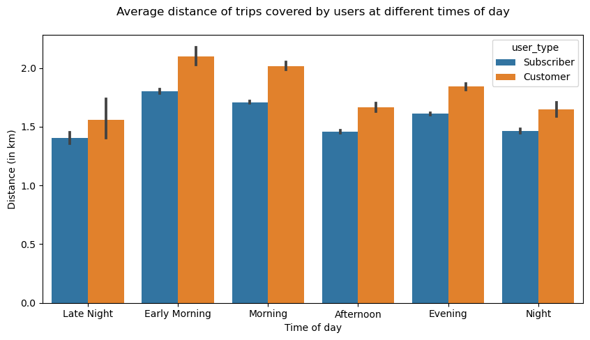

```python
plt.figure(figsize= [10, 5])
sb.barplot(data = gobike, hue = 'user_type', x = 'time_of_day', y='distance')
label('Time of day', 'Distance (in km)', 'Average distance of trips covered by users at different times of day');
```

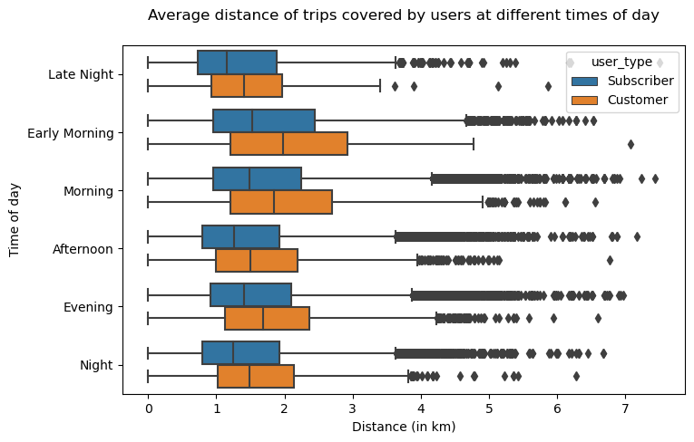

```python
plt.figure(figsize=[8,5])
sb.boxplot(data = gobike, hue = 'user_type', y = 'time_of_day', x='distance')
label('Distance (in km)', 'Time of day', 'Average distance of trips covered by users at different times of day');
```

### Observation

Although the most rides of the day are taken in the evening from earlies observations, the most distance covered on the average are Early Mornings. This could mean riders that have longer distances to cover set off at early mornings.

### Question

How does the distance covered vary across different days of the week for the users

### Visualization

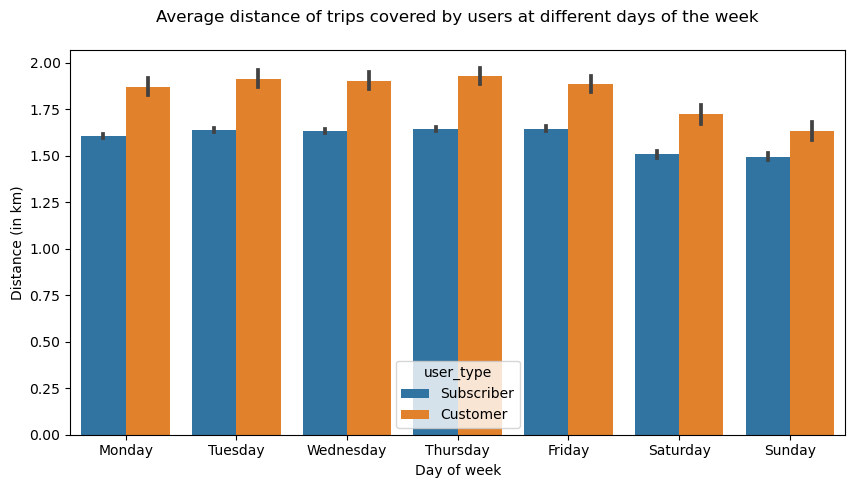

```python
plt.figure(figsize= [10, 5])
sb.barplot(data = gobike, hue = 'user_type', x = 'day_of_week', y='distance')
label('Day of week', 'Distance (in km)', 'Average distance of trips covered by users at different days of the week');
```

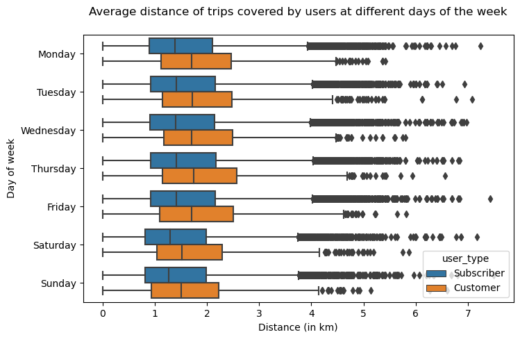

```python
plt.figure(figsize=[8,5])
sb.boxplot(data = gobike, hue = 'user_type', y = 'day_of_week', x='distance')
label('Distance (in km)', 'Day of week', 'Average distance of trips covered by users at different days of the week');
```

### Observation

Average distance of trips covered by users at different days of the week are both similar for Subscribers and Users.

### Question

How do the different users vary by distance and duration of trips

### Visualization

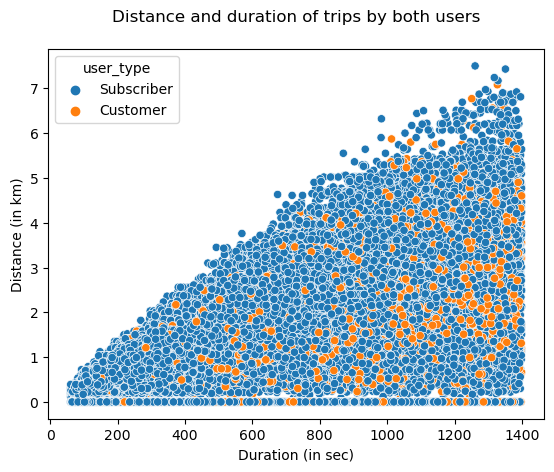

```python
sb.scatterplot(data=gobike, x='duration_sec', y='distance', hue='user_type')
label('Duration (in sec)', 'Distance (in km)', 'Distance and duration of trips by both users');
```

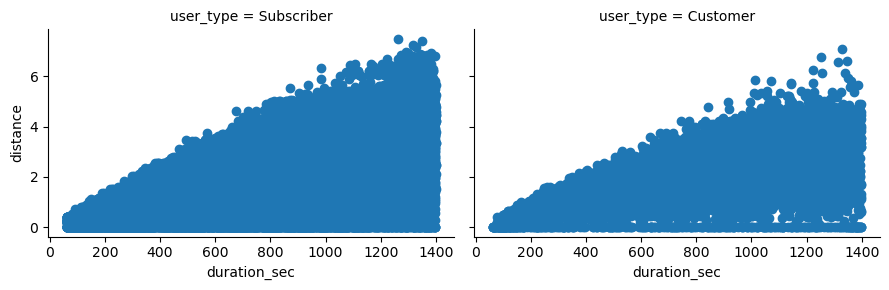

```python
g = sb.FacetGrid(data = gobike, col = 'user_type', height=3, aspect=1.5 )
g.map(plt.scatter, 'duration_sec', 'distance');
```

### Observation

Although both Subcribers and Customers follow the same pattern, there are more Customer riders with longer duration on trips.